**CSE2215** - Computer Graphics

Elmar Eisemann, Martin Skrodzki, Mathijs Molenaar, Michael Weinmann, Ricardo Marroqium

# Start-Up Check

This simple start-up project builds on top of the C++ framework used in the rest of the course, and serves as a check that the required C++ build tools are installed correctly.

Submission to brightspace is not needed for this assignment.

# Required Steps

Follow the setup guide on Brightspace on how to install Visual Studio and run the code. Make sure that you are in `x64-Debug` mode and that you open the main folder (`startup_check`), **not** the `framework` folder. Run the program and if everything is working correctly then you should see the following window:

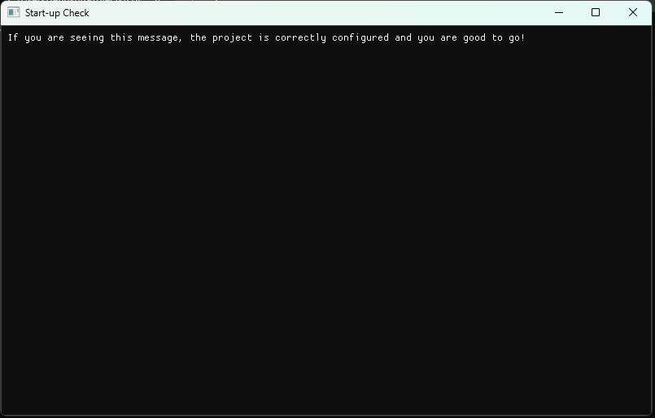

Screenshot of the startup check program

Otherwise, if there is any issue with the compilation, or if the window does not display as expected, there may be problems with your C++ build tools setup. Please contact a TA during the next lab session for help.

You can also use this program to get yourself familiar with the debugging tools, such as breakpoints, available in Visual Studio. You can find more information about breakpoints at the end of the setup guide (shared on Brightspace).

[figure not shown]

Hitting a breakpoint. The watch window at the bottom shows the current values of the variables.